# MiSeq data processing

Devin R Leopold

April 10, 2020

# Prepare environment

```r
library(tidyverse)
library(magrittr)
library(dada2)
library(Biostrings)
library(phyloseq)
```

read in and prepare sample meta data

```r
mapping <- read.delim("data/mapping.tab",header=T,row.names=1,as.is=T)
mapping %<>%
  rownames_to_column("SampID") %>%
  mutate(
    logAge=log(Age*1000),
    Site=factor(Site,levels=c("Thurston","Olaa","Laupahoehoe","Kohala","Kokee")),
    N=grepl("N",Frt_treat),
    P=grepl("P",Frt_treat)
  ) %>%
  column_to_rownames("SampID")
```

identify gene primers for trimming

```r
ITS1F <- "CTTGGTCATTTAGAGGAAGTAA"
ITS1F.rc <- dada2::rc(ITS1F)
ITS2 <- "GCTGCGTTCTTCATCGATGC"
ITS2.rc <- dada2::rc(ITS2)
```

identify paths to raw data

```r
raw.fwd <- list.files("data/MiSeq_raw/",pattern="R1_001.fastq.gz") %>% sort
raw.rev <- list.files("data/MiSeq_raw/",pattern="R2_001.fastq.gz") %>% sort
```

identify sample IDs

```r
samps <- raw.fwd %>% strsplit("_") %>% sapply(`[`,1)
```

# Trim reads

```r
if(!dir.exists("output/trim/")){
  dir.create("output/trim/", F, T)
  for(samp in samps){
    in.raw <- paste0(samp,"_") %>% grep(raw.fwd, value = T) %>% list.files("data/MiSeq_raw",pattern=., full.names = T)
    out.trim <- paste0(samp,".R1.fastq.gz") %>% file.path("output/trim",.)

    flags <- paste("-o", out.trim,
                   "-a", ITS2.rc,
                   "-e 0.2",
                   "--minimum-length 100","-l 250",
                   "--quality-cutoff 15",
                   "--quiet",
                   in.raw)
    system2("/home/harpua/miniconda3/bin/cutadapt",args=flags)
  }
}
```

identify paths to trimmed reads

```r
trimmed.fwd <- list.files("output/trim",pattern="R1.fastq", full.names = T) %>% sort
```

preview read quality of 6 randomly selected samples

```r
qual.samps <- sample(1:length(trimmed.fwd),6)
```

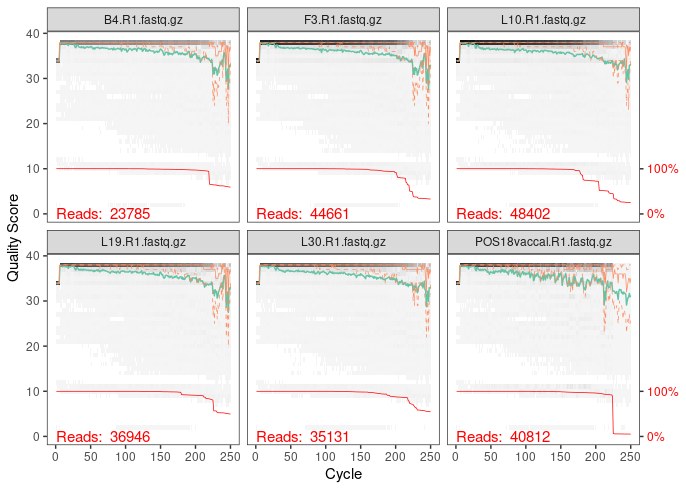

```r
plotQualityProfile(trimmed.fwd[qual.samps])
```

# Quality filter

```r
dir.create("output/dada/filt",F,T)
```

idenitfy file paths for filtering output

```r
filt.fwd <- trimmed.fwd %>% gsub("trim","dada/filt",.)
```

```r
filt <- filterAndTrim(trimmed.fwd,filt.fwd,
                      truncQ = 2, minLen = 75, maxN=0, maxEE=2, trimLeft=10,
                      rm.phix=TRUE, compress=TRUE, multithread=TRUE)
filt
```

```
##                         reads.in reads.out
## A1.R1.fastq.gz             53770     45258
## A10.R1.fastq.gz            58298     49211
## A11.R1.fastq.gz            59993     50259
## A12.R1.fastq.gz            48063     40881
## A2.R1.fastq.gz             33974     28847
## A3.R1.fastq.gz             48232     40817
## A4.R1.fastq.gz             37578     32704
## A5.R1.fastq.gz             38789     32594
## A6.R1.fastq.gz             44874     38505
## A7.R1.fastq.gz             51542     44435
## A8.R1.fastq.gz             33480     28578
## A9.R1.fastq.gz             60355     50758
## B1.R1.fastq.gz             33681     28259
## B10.R1.fastq.gz            48783     41361
## B11.R1.fastq.gz            28328     24775
## B12.R1.fastq.gz            34197     28646
## B2.R1.fastq.gz             35380     29437
## B3.R1.fastq.gz             47053     40347
## B4.R1.fastq.gz             23785     20601
## B5.R1.fastq.gz             38581     32117
## B6.R1.fastq.gz             33798     29225
## B7.R1.fastq.gz             36276     31159
## B8.R1.fastq.gz             23745     20584
## B9.R1.fastq.gz             51442     44184
## C1.R1.fastq.gz             49772     43342
## C10.R1.fastq.gz            45755     39259
## C11.R1.fastq.gz            32359     27627
## C12.R1.fastq.gz            33981     28217
## C2.R1.fastq.gz             47215     40097
## C3.R1.fastq.gz             47349     40319
## C4.R1.fastq.gz             27302     23238
## C5.R1.fastq.gz             26664     22782
## C6.R1.fastq.gz             33946     28880
## C7.R1.fastq.gz             21336     18100
## C8.R1.fastq.gz             46318     38670
## C9.R1.fastq.gz             51460     43400
## D1.R1.fastq.gz             43953     37338
## D10.R1.fastq.gz            42712     36740
## D11.R1.fastq.gz            39077     32821
```

[output cut: 70 more lines]

```
## L34.R1.fastq.gz            48277     40910
## L4.R1.fastq.gz             37053     31506
## L5.R1.fastq.gz             29128     24565
## L6.R1.fastq.gz             36270     31291
## L7.R1.fastq.gz             23264     19773
## L8.R1.fastq.gz             32526     27539
## L9.R1.fastq.gz             37670     32332
## NEG1vaccal.R1.fastq.gz      3081      1062
## NEG2vaccal.R1.fastq.gz       116        96
## NEG3vaccal.R1.fastq.gz      4163      3599
## NEG4vaccal.R1.fastq.gz       554       284
## POS18vaccal.R1.fastq.gz    40812     33723
## POS23vaccal.R1.fastq.gz    71577     61603
## POS49vaccal.R1.fastq.gz    61021     55171
## POS82vaccal.R1.fastq.gz     3014      2510
```

check quality profiles after trimming

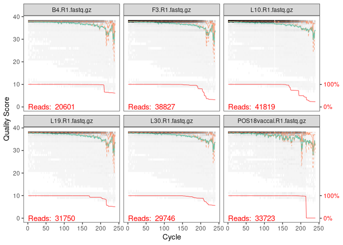

```r
plotQualityProfile(filt.fwd[qual.samps])
```

# Dereplicate

```r
derep.fwd <- derepFastq(filt.fwd, verbose=F)
```

Trim names of derep objects to just sample names

```r
names(derep.fwd) %<>% gsub(".R1.fastq.gz","",.)
```

# Learn errors

```r
set.seed(808080)
if(!file.exists("output/rds/errMod.rds")){
  err.fwd <- learnErrors(filt.fwd, multithread=TRUE, nbases = 5e08, randomize=T)
  plotErrors(err.fwd, nominalQ=TRUE)
  saveRDS(err.fwd,"output/rds/errMod.rds")
}else{err.fwd <- readRDS("output/rds/errMod.rds")}
```

# Denoise

```r
if(!file.exists("output/rds/dada.rds")){
  dada.fwd <- dada(derep.fwd, err=err.fwd, multithread=TRUE, pool=T,
                   GREEDY=F, OMEGA_A=1e-45, MIN_ABUNDANCE=4)
  saveRDS(dada.fwd,"output/rds/dada.rds")
}else(dada.fwd <- readRDS("output/rds/dada.rds"))
```

```
## $A1
## dada-class: object describing DADA2 denoising results
## 145 sequence variants were inferred from 16741 input unique sequences.
## Key parameters: OMEGA_A = 1e-45, OMEGA_C = 1e-40, BAND_SIZE = 16
##
## $A10
## dada-class: object describing DADA2 denoising results
## 143 sequence variants were inferred from 18420 input unique sequences.
## Key parameters: OMEGA_A = 1e-45, OMEGA_C = 1e-40, BAND_SIZE = 16
##
## $A11
## dada-class: object describing DADA2 denoising results
## 167 sequence variants were inferred from 18623 input unique sequences.
## Key parameters: OMEGA_A = 1e-45, OMEGA_C = 1e-40, BAND_SIZE = 16
##
## $A12
## dada-class: object describing DADA2 denoising results
## 154 sequence variants were inferred from 14760 input unique sequences.
## Key parameters: OMEGA_A = 1e-45, OMEGA_C = 1e-40, BAND_SIZE = 16
##
## $A2
## dada-class: object describing DADA2 denoising results
## 106 sequence variants were inferred from 11449 input unique sequences.
## Key parameters: OMEGA_A = 1e-45, OMEGA_C = 1e-40, BAND_SIZE = 16
##
## $A3
## dada-class: object describing DADA2 denoising results
## 170 sequence variants were inferred from 14759 input unique sequences.
## Key parameters: OMEGA_A = 1e-45, OMEGA_C = 1e-40, BAND_SIZE = 16
##
## $A4
## dada-class: object describing DADA2 denoising results
## 130 sequence variants were inferred from 13461 input unique sequences.
## Key parameters: OMEGA_A = 1e-45, OMEGA_C = 1e-40, BAND_SIZE = 16
##
## $A5
## dada-class: object describing DADA2 denoising results
## 133 sequence variants were inferred from 13387 input unique sequences.
## Key parameters: OMEGA_A = 1e-45, OMEGA_C = 1e-40, BAND_SIZE = 16
##
```

[output cut: 564 more lines]

```
##
## $POS23vaccal
## dada-class: object describing DADA2 denoising results
## 84 sequence variants were inferred from 15249 input unique sequences.
## Key parameters: OMEGA_A = 1e-45, OMEGA_C = 1e-40, BAND_SIZE = 16
##
## $POS49vaccal
## dada-class: object describing DADA2 denoising results
## 54 sequence variants were inferred from 13951 input unique sequences.
## Key parameters: OMEGA_A = 1e-45, OMEGA_C = 1e-40, BAND_SIZE = 16
##
## $POS82vaccal
## dada-class: object describing DADA2 denoising results
## 11 sequence variants were inferred from 1738 input unique sequences.
## Key parameters: OMEGA_A = 1e-45, OMEGA_C = 1e-40, BAND_SIZE = 16
```

Make sequence table

```r
seqtab <- dada.fwd  %>% makeSequenceTable %>% collapseNoMismatch
```

# Remove chimeras

```r
seqtab %<>% removeBimeraDenovo(method="consensus", multithread=TRUE,verbose=T)
```

```
## Identified 26 bimeras out of 1107 input sequences.
```

# Make phyloseq object

Extract sequences

```r
seqs <- getSequences(seqtab) %>% DNAStringSet()
names(seqs) <- getSequences(seqtab)
```

Assign taxonomy with UNITE fungal database v8.2

```r
taxa <- assignTaxonomy(seqs,"data/taxDB/UNITEv8.2S.ITS1_curated.fasta.gz", multithread = T)
```

```
## UNITE fungal taxonomic reference detected.
```

combine

```r
(phy <- phyloseq(otu_table(seqtab,taxa_are_rows = F),
                refseq(seqs),
                tax_table(taxa),
                sample_data(mapping)))
```

```
## phyloseq-class experiment-level object
## otu_table()   OTU Table:         [ 1081 taxa and 124 samples ]
## sample_data() Sample Data:       [ 124 samples by 12 sample variables ]
## tax_table()   Taxonomy Table:    [ 1081 taxa by 7 taxonomic ranks ]
## refseq()      DNAStringSet:      [ 1081 reference sequences ]
```

# cluster OTUs

```r
cluster <- function(phy.in,method="single",dissimilarity=0.01){
  require(DECIPHER)
  clusters <- DistanceMatrix(refseq(phy.in), includeTerminalGaps = T, processors=NULL) %>%
    IdClusters(method=method, cutoff=dissimilarity, processors=NULL)
  clusters[,1] %<>% as.character()
  tax.holder <- tax_table(phy.in)
  tax_table(phy.in) <- clusters %>% as.matrix %>% tax_table
  phy.in %<>% speedyseq::tax_glom("cluster")
  tax_table(phy.in) <- tax.holder
  return(phy.in)
}
phy %<>% cluster
```

```
## ================================================================================
##
## Time difference of 0.06 secs
##
## ================================================================================
##
## Time difference of 0.04 secs
```

# Taxonomy filter

Use UNITE “all Eukaryotes” database to filter non-fungal amplicons (database was trimmed to ITS1)

```r
taxa.filter <- assignTaxonomy(refseq(phy),"data/taxDB/UNITE_allEuk_trimmed.fasta.gz", multithread = T)
```

```
## UNITE fungal taxonomic reference detected.
```

```r
(phy %<>% prune_taxa(grepl("k__Fungi",taxa.filter[,1]),.))
```

```
## phyloseq-class experiment-level object
## otu_table()   OTU Table:         [ 685 taxa and 124 samples ]
## sample_data() Sample Data:       [ 124 samples by 12 sample variables ]
## tax_table()   Taxonomy Table:    [ 685 taxa by 7 taxonomic ranks ]
## refseq()      DNAStringSet:      [ 685 reference sequences ]
```

# Negative controls

max seq count in neg controls

```r
maxNegAbund <- phy %>% subset_samples(Control=="neg") %>% otu_table %>% data.frame %>% apply(2,max)
```

find mean seq abund in env. samps

```r
meanAbund <- phy %>% subset_samples(is.na(Control)) %>% otu_table %>% apply(2,mean)
```

filter likely contaminants (max abund in control samps greater than mean abund in env. samps.)

```r
phy %<>% prune_taxa(maxNegAbund < meanAbund,.) %>%
  subset_samples(is.na(Control)) #Also remove control samps. from phy object
```

set ascending OTU names

```r
tmp.names <- phy %>%
  transform_sample_counts(function(x){x/sum(x)}) %>%
  taxa_sums() %>%
  order(decreasing = T)
names(tmp.names) <- paste0("OTU.",1:ntaxa(phy))
taxa_names(phy) <- names(sort(tmp.names))
```

# Subset ERM

identify taxa that are in likely ERM orders)

```r
ERM_bytax <- tax_table(phy)[,'Order'] %in% c("Chaetothyriales","Helotiales","Sebacinales","Trechisporales") |
  tax_table(phy)[,'Genus'] %in% c("Oidiodendron","Leohumicola")
```

subset phyloseq object

```r
(phy.erm <- phy %>% prune_taxa(ERM_bytax,.))
```

```
## phyloseq-class experiment-level object
## otu_table()   OTU Table:         [ 211 taxa and 116 samples ]
## sample_data() Sample Data:       [ 116 samples by 12 sample variables ]
## tax_table()   Taxonomy Table:    [ 211 taxa by 7 taxonomic ranks ]
## refseq()      DNAStringSet:      [ 211 reference sequences ]
```

# Summary

```r
dir.create("output/rds",F)
saveRDS(phy,"output/rds/phy.rds")
saveRDS(phy.erm,"output/rds/phy.erm.rds")
```